# **PCFL 2022: Week 4 wrap-up**

## Last week’s games

| Winner | Winner’s score | Loser | Loser’s score |
| --- | --- | --- | --- |
| The Juniors | 108.80 | Pigskin on the Gridiron | 102.98 |
| Southern Sharks | 143.96 | Middle Earth Hangry Hobbits | 106.68 |
| KC Gophers | 106.92 | Georgia Peanuts | 74.76 |
| Athens Team Sasquatch | 129.62 | The G.O.A.T. | 123.16 |
| Jumpin’ Jaheims | 136.26 | Captain Clairvoyant | 107.38 |

Last week’s game of the week was Jacob vs. Robbie, and it was a nail biter! Robbie edged out Jacob by just over 6 points, with plenty of points scored on both sides.

The mismatch of the week was Scott and Sarah, and as was predicted, it wasn’t a close game. 10th seed Sarah blew our top scoring Hobbits away, in yet another case of matchup back luck for Scott.

In other games, Erin/Trav edged out Richard, Crissy continued her strong start against me, and Evan stayed unbeaten with a win against Brian.

## Best performances

### Best players overall

Here’s last week’s **10 best performing starters.**

| Player | Position | NFL Team | Points | PCFL Team |
| --- | --- | --- | --- | --- |
| Josh Jacobs | RB | OAK | 32.00 | Athens Team Sasquatch |
| Austin Ekeler | RB | LAC | 31.90 | Jumpin’ Jaheims |
| Miles Sanders | RB | PHI | 28.60 | Athens Team Sasquatch |
| Russell Wilson | QB | DEN | 26.98 | Pigskin on the Gridiron |
| Mike Evans | WR | TBB | 26.30 | Jumpin’ Jaheims |
| Justin Jefferson | WR | MIN | 26.00 | Middle Earth Hangry Hobbits |
| Josh Allen | QB | BUF | 23.52 | Athens Team Sasquatch |
| Jamaal Williams | RB/WR/TE | DET | 23.40 | Southern Sharks |
| Patrick Mahomes | QB | KCC | 23.36 | Southern Sharks |
| Dameon Pierce | RB/WR/TE | HOU | 22.90 | The Juniors |

Lots of running backs this week! Josh Jacobs and Miles Sanders are definitely not the usual suspects, and Russell Wilson had been off to a rough start. Team Sasquatch and the Jumpin’ Jaheims both had some nice performances this week.

### Best players per team

Here’s last week’s top players **on each team.**

| Player | Position | NFL Team | Points | PCFL Team |
| --- | --- | --- | --- | --- |
| Josh Jacobs | RB | OAK | 32.00 | Athens Team Sasquatch |
| J.K. Dobbins | BE | BAL | 20.30 | Captain Clairvoyant |
| Jalen Hurts | QB | PHI | 15.96 | Georgia Peanuts |
| Austin Ekeler | RB | LAC | 31.90 | Jumpin’ Jaheims |
| Rashaad Penny | BE | SEA | 28.20 | KC Gophers |
| T.J. Hockenson | BE | DET | 35.90 | Middle Earth Hangry Hobbits |
| Russell Wilson | QB | DEN | 26.98 | Pigskin on the Gridiron |
| Jamaal Williams | RB/WR/TE | DET | 23.40 | Southern Sharks |
| 49ers D/ST | DST | SFO | 22.00 | The G.O.A.T. |
| Dameon Pierce | RB/WR/TE | HOU | 22.90 | The Juniors |

Scott’s really kicking himself for leaving T.J. Hockenson on his bench. And check out the high flying 49ers defense on Jacob’s squad.

### Best bench

Who won the **best scoring bench** award last week?

| Team | Bench points |
| --- | --- |
| Middle Earth Hangry Hobbits | 100.40 |
| Captain Clairvoyant | 81.34 |
| KC Gophers | 71.55 |
| Southern Sharks | 65.24 |
| Pigskin on the Gridiron | 58.90 |
| The G.O.A.T. | 44.84 |
| Jumpin’ Jaheims | 44.76 |
| Georgia Peanuts | 41.94 |
| Athens Team Sasquatch | 25.06 |
| The Juniors | 15.78 |

Hobbits leading the pack this week.

Here’s the season’s bench standings:

| Team | Bench points |
| --- | --- |
| Middle Earth Hangry Hobbits | 340.28 |
| KC Gophers | 274.37 |
| The G.O.A.T. | 273.72 |
| Southern Sharks | 250.70 |
| Pigskin on the Gridiron | 250.01 |
| Jumpin’ Jaheims | 249.39 |
| The Juniors | 245.38 |
| Captain Clairvoyant | 209.20 |
| Athens Team Sasquatch | 182.92 |
| Georgia Peanuts | 181.30 |

Scott’s starting to pull away with this one, with Crissy and Jacob neck and neck behind him.

### Best optimized lineups

I compared the actual starting lineups for each team to the hypothetical *best* starting lineup the owner could have started. The table below shows the actual points the team scored, the top score they could have had, and an “optimization” percentage that compares to the two.

| PCFL Team | Actual points | Best lineup | Optimization rate |
| --- | --- | --- | --- |
| Athens Team Sasquatch | 129.62 | 130.62 | 99% |
| Southern Sharks | 143.96 | 150.66 | 96% |
| The Juniors | 108.80 | 115.20 | 94% |
| Georgia Peanuts | 74.76 | 81.46 | 92% |
| Jumpin’ Jaheims | 136.26 | 148.46 | 92% |
| Pigskin on the Gridiron | 102.98 | 117.38 | 88% |
| The G.O.A.T. | 123.16 | 142.94 | 86% |
| Captain Clairvoyant | 107.38 | 133.98 | 80% |
| KC Gophers | 106.92 | 134.12 | 80% |
| Middle Earth Hangry Hobbits | 106.68 | 168.68 | 63% |

Nice work, Team Sasquatch and Southern Sharks.

For the *whole season*, here’s a graph of actual points scored vs. optimized points given the roster.

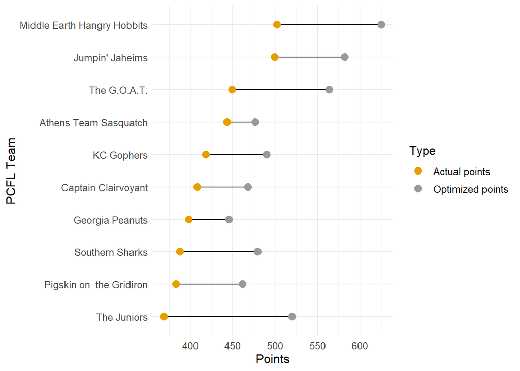

We’ll see what happens as we get into bye weeks, but Evan’s definitely having a nice season both in actual and possible points.

### Best additions

There were 22 players added last week. Which was the **best new addition**?

| PCFL Team | Player | NFL Team | Position | Points |
| --- | --- | --- | --- | --- |
| Southern Sharks | Jamaal Williams | DET | RB | 23.4 |
| Captain Clairvoyant | Damien Harris | NEP | RB | 14.9 |
| Southern Sharks | Isaiah McKenzie | BUF | WR | 12.4 |
| Southern Sharks | Romeo Doubs | GBP | WR | 11.2 |
| Georgia Peanuts | Khalil Herbert | CHI | RB | 10.6 |
| Georgia Peanuts | Dallas Goedert | PHI | TE | 9.7 |
| Captain Clairvoyant | Tyler Conklin | NYJ | TE | 6.7 |
| Athens Team Sasquatch | Vikings D/ST | MIN | DST | 6.0 |
| Georgia Peanuts | Brian Robinson | WAS | RB | NA |
| Georgia Peanuts | Allen Lazard | GBP | WR | NA |
| Georgia Peanuts | Devin Duvernay | BAL | WR | NA |
| Georgia Peanuts | Chase Edmonds | MIA | RB | NA |
| Georgia Peanuts | Brett Maher | DAL | K | NA |
| Southern Sharks | Tyler Allgeier | ATL | RB | NA |
| Southern Sharks | Michael Gallup | DAL | WR | NA |
| Southern Sharks | Jaguars D/ST | JAC | DST | NA |
| Captain Clairvoyant | Jared Goff | DET | QB | NA |
| Captain Clairvoyant | Broncos D/ST | DEN | DST | NA |
| Athens Team Sasquatch | Greg Joseph | MIN | K | NA |
| Athens Team Sasquatch | Zach Wilson | NYJ | QB | NA |
| Athens Team Sasquatch | Nyheim Hines | IND | RB | NA |
| Jumpin’ Jaheims | Isiah Pacheco | KCC | RB | NA |

Very nice running back pickup for Sarah.

### Best team performances

Here’s a list of the **top five scoring performances** so far this season.

| PCFL Team | Week | Score | Result |
| --- | --- | --- | --- |
| Middle Earth Hangry Hobbits | 1 | 148.06 | W |
| Georgia Peanuts | 2 | 147.22 | W |
| Southern Sharks | 4 | 143.96 | W |
| Jumpin’ Jaheims | 4 | 136.26 | W |
| Middle Earth Hangry Hobbits | 2 | 133.76 | L |

Scott’s week 1 still is our top performance this season, but both Sarah and Evan got into the top 5 this week.

## Looking ahead

### League standings

| PCFL Team | Division | Points scored | Avg points | W | L | Team points |
| --- | --- | --- | --- | --- | --- | --- |
| Jumpin’ Jaheims | Grits | 499.62 | 124.905 | 4 | 0 | 8 |
| Athens Team Sasquatch | Grits | 443.58 | 110.895 | 4 | 0 | 7 |
| The G.O.A.T. | Grits | 449.46 | 112.365 | 2 | 2 | 6 |
| Middle Earth Hangry Hobbits | Hot Dish | 502.16 | 125.540 | 1 | 3 | 4 |
| KC Gophers | Hot Dish | 418.34 | 104.585 | 3 | 1 | 4 |
| Georgia Peanuts | Hot Dish | 398.40 | 99.600 | 2 | 2 | 3 |
| The Juniors | Hot Dish | 368.90 | 92.225 | 2 | 2 | 3 |
| Southern Sharks | Hot Dish | 387.62 | 96.905 | 1 | 3 | 2 |
| Captain Clairvoyant | Grits | 408.36 | 102.090 | 1 | 3 | 2 |
| Pigskin on the Gridiron | Grits | 383.16 | 95.790 | 0 | 4 | 1 |

### If the season ended today…

Current playoff teams (ESPN): Evan and Crissy as division winners, Robbie and Jacob as wildcards

Current playoff teams (Team points): Evan, Robbie, Jacob, and Scott

### Next week’s matchups

| Team 1 | Team 2 |
| --- | --- |
| Athens Team Sasquatch (Avg. points: 110.9) | Jumpin’ Jaheims (Avg. points: 124.9) |
| Captain Clairvoyant (Avg. points: 102.09) | Southern Sharks (Avg. points: 96.9) |
| Georgia Peanuts (Avg. points: 99.6) | The Juniors (Avg. points: 92.22) |
| KC Gophers (Avg. points: 104.59) | Middle Earth Hangry Hobbits (Avg. points: 125.54) |
| Pigskin on the Gridiron (Avg. points: 95.79) | The G.O.A.T. (Avg. points: 112.36) |

There can only be one unbeaten team, and this week’s featured matchup between Robbie and Evan will determine which owner will carry that title. Meanwhile, Scott tries to get back in the win column against the resurgent Gophers. Two family matchups the week: Richard vs. Jacob in the Battle of the Pages and me vs. Erin/Trav. Lastly, Sarah tries to keep the wins going against Brian.

Good luck, y’all!